# Lösungen

## Datenaufbereitung

```r
# Sammlung von Paketen, viel zu Datenmanipulation
library("tidyverse")
# Für die Berechnung der Multilevel Modelle
library("nlme")
# Für die Weiterverarbeitung der Ergebnisse des Pakets nlme
library("broom.mixed")
# Wird einmal für die Darstellung einer Tabelle benötigt
library("kableExtra")
```

2. Laden Sie die Datendatei `gpa2.csv` mit dem Befehl `read_csv2()`. Speichern Sie die Daten in einem neuen Objekt unter dem Namen `gpa_data`. Betrachten Sie die Daten in dem Objekt `gpa_data` näher. Benutzen Sie hierzu die Befehle `head()` und `str()`.

```r
gpa_data <- read.csv2(file = "./data/gpa2.csv")
head(gpa_data)
```

```
##   student sex highgpa gpa1 gpa2 gpa3 gpa4 gpa5 gpa6 job1 job2 job3 job4 job5
## 1       1   1     2.8  2.3  2.1  3.0  3.0  3.0  3.3    2    2    2    2    2
## 2       2   0     2.5  2.2  2.5  2.6  2.6  3.0  2.8    2    3    2    2    2
## 3       3   1     2.5  2.4  2.9  3.0  2.8  3.3  3.4    2    2    2    3    2
## 4       4   0     3.8  2.5  2.7  2.4  2.7  2.9  2.7    3    2    2    2    2
## 5       5   0     3.1  2.8  2.8  2.8  3.0  2.9  3.1    2    2    2    2    2
## 6       6   1     2.9  2.5  2.4  2.4  2.3  2.7  2.8    2    3    3    2    3
##   job6 admitted
## 1    2        1
## 2    2        0
## 3    2        1
## 4    2        0
## 5    2        1
## 6    3        0
```

```r
str(gpa_data)
```

```
## 'data.frame':    200 obs. of  16 variables:
##  $ student : int  1 2 3 4 5 6 7 8 9 10 ...
##  $ sex     : int  1 0 1 0 0 1 0 1 0 0 ...
##  $ highgpa : num  2.8 2.5 2.5 3.8 3.1 2.9 2.3 3.9 2 2.8 ...
##  $ gpa1    : num  2.3 2.2 2.4 2.5 2.8 2.5 2.4 2.8 2.8 2.8 ...
##  $ gpa2    : num  2.1 2.5 2.9 2.7 2.8 2.4 2.4 2.8 2.7 2.8 ...
##  $ gpa3    : num  3 2.6 3 2.4 2.8 2.4 2.8 3.1 2.7 3 ...
##  $ gpa4    : num  3 2.6 2.8 2.7 3 2.3 2.6 3.3 3.1 2.7 ...
##  $ gpa5    : num  3 3 3.3 2.9 2.9 2.7 3 3.3 3.1 3 ...
##  $ gpa6    : num  3.3 2.8 3.4 2.7 3.1 2.8 3 3.4 3.5 3 ...
##  $ job1    : int  2 2 2 3 2 2 3 2 2 2 ...
##  $ job2    : int  2 3 2 2 2 3 2 2 2 2 ...
##  $ job3    : int  2 2 2 2 2 3 3 2 3 2 ...
##  $ job4    : int  2 2 3 2 2 2 2 2 2 3 ...
##  $ job5    : int  2 2 2 2 2 3 2 2 2 2 ...
##  $ job6    : int  2 2 2 2 2 3 2 2 2 2 ...
##  $ admitted: int  1 0 1 0 1 0 1 1 9 1 ...
```

4. Wählen Sie mit dem Befehl `select()` die für die Analyse relevanten Daten `student`, `sex` und `gpa1` bis `gpa6` aus. Im Anschluss benennen Sie mit dem Befehl `rename()` den Variablennamen `student` in `student_id` um. Betrachten Sie die Ergebnisse der Datenmanipulation.

```r
gpa_data <- select(gpa_data, student, sex, starts_with("gpa"))
gpa_data <- rename(gpa_data, student_id = student)
head(gpa_data)
```

```
##   student_id sex gpa1 gpa2 gpa3 gpa4 gpa5 gpa6
## 1          1   1  2.3  2.1  3.0  3.0  3.0  3.3
## 2          2   0  2.2  2.5  2.6  2.6  3.0  2.8
## 3          3   1  2.4  2.9  3.0  2.8  3.3  3.4
## 4          4   0  2.5  2.7  2.4  2.7  2.9  2.7
## 5          5   0  2.8  2.8  2.8  3.0  2.9  3.1
## 6          6   1  2.5  2.4  2.4  2.3  2.7  2.8
```

5. Strukturieren Sie die Daten mit dem Befehl `pivot_longer()` um. Überführen Sie dabei die Variablen `gpa1` bis `gpa6` von dem Wide-Format in das Long-Format. Die neu entstehende Spalte mit den GPA-Werten für alle Messzeitpunkte soll dabei den Variablennamen `gpa` erhalten und die Namen der Variablen `gpa1` bis `gpa6` sollen in eine Spalte mit dem Namen `time` überführt werden. Betrachten Sie die Ergebnisse der Umstrukturierung.

```r
gpa_data_long <- pivot_longer(gpa_data,
                    cols = c("gpa1", "gpa2", "gpa3", "gpa4", "gpa5", "gpa6"),
                    names_to = "time",
                    values_to = "gpa")
gpa_data_long
```

```
## # A tibble: 1,200 × 4
##    student_id   sex time    gpa
##         <int> <int> <chr> <dbl>
##  1          1     1 gpa1    2.3
##  2          1     1 gpa2    2.1
##  3          1     1 gpa3    3
##  4          1     1 gpa4    3
##  5          1     1 gpa5    3
##  6          1     1 gpa6    3.3
##  7          2     0 gpa1    2.2
##  8          2     0 gpa2    2.5
##  9          2     0 gpa3    2.6
## 10          2     0 gpa4    2.6
## # … with 1,190 more rows
```

6. Im Folgenden wird die Variable `time` überschrieben und eine neue Zeitvariable mit den Werten 0 bis 5 gebildet. Überprüfen Sie mit der Funktion `print()`, ob die Werte korrekt erstellt wurden. Wie beurteilen Sie, dass der erste Messzeitpunkt den Wert 0 erhalten hat?

```r
gpa_data_long <- gpa_data_long%>%
  group_by(student_id)%>%
  mutate(time = 1:n()-1)
print(gpa_data_long, n = 15)
```

```
## # A tibble: 1,200 × 4
## # Groups:   student_id [200]
##    student_id   sex  time   gpa
##         <int> <int> <dbl> <dbl>
##  1          1     1     0   2.3
##  2          1     1     1   2.1
##  3          1     1     2   3
##  4          1     1     3   3
##  5          1     1     4   3
##  6          1     1     5   3.3
##  7          2     0     0   2.2
##  8          2     0     1   2.5
##  9          2     0     2   2.6
## 10          2     0     3   2.6
## 11          2     0     4   3
## 12          2     0     5   2.8
## 13          3     1     0   2.4
## 14          3     1     1   2.9
## 15          3     1     2   3
## # … with 1,185 more rows
```

7. Das Objekt `gpa_subsample` enthält die Messwerte von vier Personen (IDs 14, 21, 43, 68). Im Folgenden soll für diese Personen der Verlauf der GPA-Werte über die Zeit dargestellt werden. Dabei werden verschiedene Funktionen des Pakets `ggplot2` benutzt. Hierzu müssen zunächst in der Funktion `ggplot()` die Variablen `time` und `gpa` als x- bzw. y-Wert angegeben werden. Damit die GPA-Werte einer Person eindeutig zugeordnet werden können, muss für das Argument `group` zusätzlich die Variable `student_id` angegeben werden. Betrachten Sie die Ergebnisse der im Objekt `graph_cases` abgespeicherten Graphik.

```r
gpa_subsample <- gpa_data_long%>%
  filter(student_id %in% c(14, 21, 43, 68))
gpa_subsample
```

```
## # A tibble: 24 × 4
## # Groups:   student_id [4]
##    student_id   sex  time   gpa
##         <int> <int> <dbl> <dbl>
##  1         14     1     0   2.4
##  2         14     1     1   3
##  3         14     1     2   2.9
##  4         14     1     3   3
##  5         14     1     4   3.3
##  6         14     1     5   3.4
##  7         21     1     0   2.6
##  8         21     1     1   2.4
##  9         21     1     2   2.5
## 10         21     1     3   2.5
## # … with 14 more rows
```

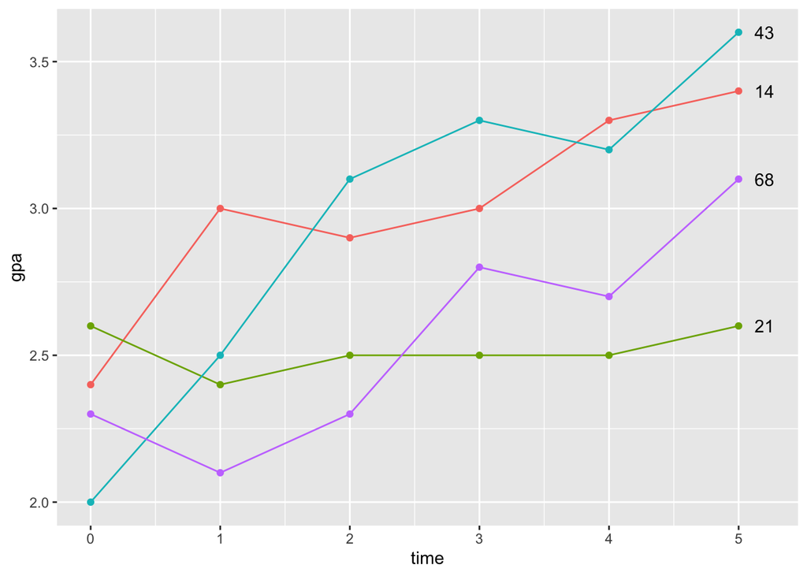

```r
graph_cases <- ggplot(gpa_subsample, aes(x = time, y = gpa, group = student_id)) +
               # Angabe, dass die Werte als Linien dargestellt werden sollen
               geom_line(aes(color = as.factor(student_id))) +
               # Die Werte der Personen sollen zusätzlich als Punkte dargestellt werden
               geom_point(aes(color = as.factor(student_id))) +
               # Die Gerade sollen mit der ID beschriftet werden
               geom_text(data = filter(gpa_subsample, time == last(time)),
                         aes(label = as.factor(student_id)),
                         position = position_nudge(x = 0.2),
                         check_overlap = TRUE) +
               theme(legend.position = "none")
graph_cases
```

## Multilevel Modeling

```r
mod1 <- lme(gpa ~ time, random = ~ 1 + time | student_id, data = gpa_data_long)
summary(mod1)
```

```
## Linear mixed-effects model fit by REML
##   Data: gpa_data_long
##        AIC     BIC    logLik
##   272.9566 303.487 -130.4783
##
## Random effects:
##  Formula: ~1 + time | student_id
##  Structure: General positive-definite, Log-Cholesky parametrization
##             StdDev     Corr
## (Intercept) 0.21259026 (Intr)
## time        0.06711178 -0.098
## Residual    0.20588283
##
## Fixed effects:  gpa ~ time
##                 Value   Std.Error  DF   t-value p-value
## (Intercept) 2.5992143 0.018357249 999 141.59062       0
## time        0.1063143 0.005884789 999  18.06595       0
##  Correlation:
##      (Intr)
## time -0.345
##
## Standardized Within-Group Residuals:
##         Min          Q1         Med          Q3         Max
## -3.26951121 -0.53771385 -0.01277499  0.53258654  3.19388035
##
## Number of Observations: 1200
## Number of Groups: 200
```

2. Das Objekt `mod1` enthält die Ergebnisse des Random-Intercept, Random-Slope Modells. Wenden Sie auf das Objekt `mod1` die Funktion `tidy()`aus dem Paket `broom.mixed` an. In der Funktion setzen Sie dabei den Wert des Arguments `conf.int` auf `TRUE` und geben für das Argument `conf.level` den Wert `0.95` an. Dadurch werden die Konfidenzintervalle der Parameter geschätzt und die Signifikanz der zufälligen Effekte kann nun zusätzlich beurteilt werden.

```r
mod1_coef <- tidy(mod1, conf.int = TRUE, conf.level = 0.95)
kbl(mod1_coef, digits = 2) %>%
  kable_styling(bootstrap_options = "striped")
```

| effect | group | term | estimate | std.error | df | statistic | p.value | conf.low | conf.high |
| --- | --- | --- | --- | --- | --- | --- | --- | --- | --- |
| fixed | fixed | (Intercept) | 2.60 | 0.02 | 999 | 141.59 | 0 | 2.56 | 2.64 |
| fixed | fixed | time | 0.11 | 0.01 | 999 | 18.07 | 0 | 0.09 | 0.12 |
| ran_pars | student_id | sd_(Intercept) | 0.21 |  |  |  |  | 0.18 | 0.25 |
| ran_pars | student_id | cor_time.(Intercept) | -0.10 |  |  |  |  | -0.29 | 0.10 |
| ran_pars | student_id | sd_time | 0.07 |  |  |  |  | 0.06 | 0.08 |
| ran_pars | Residual | sd_Observation | 0.21 |  |  |  |  |  |  |

3. Die Objekte `fix_intercept` und `fix_slope` enthalten die festen Effekte vom Random-Intercept, Random-Slope Modell aus dem Objekt `mod1`. Erweitern Sie die erste Graphik im Objekt `graph_cases` und stellen Sie zusätzlich die Gerade dar, die über die festen Effekte geschätzt wird. Für die Erweiterung nehmen Sie die Funktion `geom_abline()` aus dem Paket `ggplot2`. Betrachten Sie im Anschluss die Ergebnisse der neuen Graphik. Entspricht die Graphik Ihren Erwartungen?

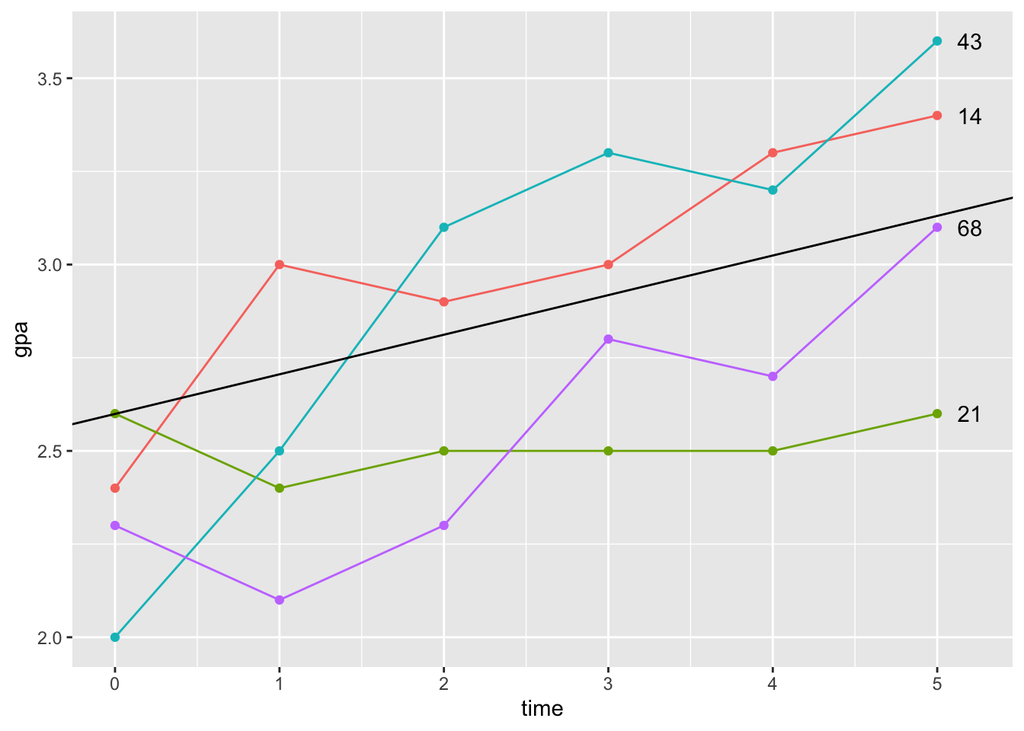

```r
fix_intercept <- summary(mod1)$coef$fixed[[1]]
fix_slope <- summary(mod1)$coef$fixed[[2]]

graph_fixed <- graph_cases +
               geom_abline(intercept = fix_intercept, slope = fix_slope)
graph_fixed
```

4. In dem Objekt `mod1` sind die Ergebnisse des Random-Intercept, Random-Slope Modell gespeichert. Wenden Sie die Funktion `augment()` aus dem Paket `broom.mixed` auf das Objekt an. Betrachten Sie im Anschluss die von der Funktion ausgegebenen Werte und versuchen ihre Bedeutung zu erfassen. Bei der Variable `.fitted` handelt es sich um individuell vorhergesagten Werte der Personen. Um die Bedeutung dieser Werte noch besser zu verstehen, sollen sie in der nächsten Übung graphisch dargestellt werden.

```r
mod1_data <- augment(mod1)
mod1_data
```

```
## # A tibble: 1,200 × 7
##    student_id   sex  time   gpa .fitted   .resid .fixed
##         <int> <int> <dbl> <dbl>   <dbl>    <dbl>  <dbl>
##  1          1     1     0   2.3    2.40 -0.0970    2.60
##  2          1     1     1   2.1    2.56 -0.463     2.71
##  3          1     1     2   3      2.73  0.271     2.81
##  4          1     1     3   3      2.90  0.105     2.92
##  5          1     1     4   3      3.06 -0.0615    3.02
##  6          1     1     5   3.3    3.23  0.0724    3.13
##  7          2     0     0   2.2    2.39 -0.189     2.60
##  8          2     0     1   2.5    2.49  0.00680   2.71
##  9          2     0     2   2.6    2.60  0.00228   2.81
## 10          2     0     3   2.6    2.70 -0.102     2.92
## # … with 1,190 more rows
```

5. Das Objekt `mod1_subsample` enthält die Daten der Substichprobe, die über die `augment`-Funktion gewonnen wurde. Erweitern Sie die zweite Graphik `graph_fixed`, um die individuell geschätzten Geradengleichungen. Hierzu müssen in der Funktion `geom_line` als x- und als y-Wert die Variablen `time` und `fitted` angegeben werden.

```r
mod1_subsample <- filter(mod1_data, student_id %in% c(14, 21, 43, 68))
mod1_subsample
```

```
## # A tibble: 24 × 7
##    student_id   sex  time   gpa .fitted  .resid .fixed
##         <int> <int> <dbl> <dbl>   <dbl>   <dbl>  <dbl>
##  1         14     1     0   2.4    2.62 -0.217    2.60
##  2         14     1     1   3      2.77  0.232    2.71
##  3         14     1     2   2.9    2.92 -0.0194   2.81
##  4         14     1     3   3      3.07 -0.0705   2.92
##  5         14     1     4   3.3    3.22  0.0784   3.02
##  6         14     1     5   3.4    3.37  0.0272   3.13
##  7         21     1     0   2.6    2.47  0.135    2.60
##  8         21     1     1   2.4    2.50 -0.0957   2.71
##  9         21     1     2   2.5    2.53 -0.0263   2.81
## 10         21     1     3   2.5    2.56 -0.0569   2.92
## # … with 14 more rows
```

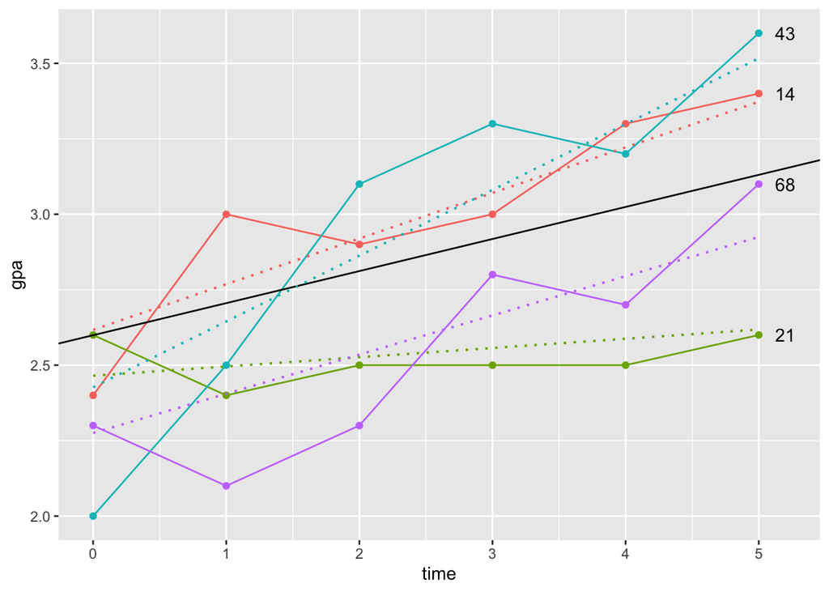

```r
graph_indi <- graph_fixed +
              geom_line(data = mod1_subsample,
                        aes(x = time, y = .fitted,
                            color = as.factor(student_id)),
                        linetype = "dotted",
                        size = 0.7
                        )

graph_indi
```